# Classifying SPAM Email using BERT

# **A model to classify spam Email using BERT**

Hugo Hiraoka > hhiraokawatts@gmail.com

**From Cisco:** Spam email is unsolicited and unwanted junk email sent out in bulk to an indiscriminate recipient list. Typically, spam is sent for commercial purposes. It can be sent in massive volume by botnets, networks of infected computers.

[figure not shown]

**Why do people send out spam email?** Often, spam email is sent for commercial purposes. While some people view it as unethical, many businesses still use spam. The cost per email is incredibly low, and businesses can send out mass quantities consistently. Spam email can also be a malicious attempt to gain access to your computer.

**Is spam email dangerous?** Spam email can be dangerous. It can include malicious links that can infect your computer with malware. Do not click links in spam. Dangerous spam emails often sound urgent, so you feel the need to act. Keep reading to learn about some of the basic spam types.

**How do you deploy anti-spam tactics?** Spam email can be difficult to stop, as it can be sent from botnets. Botnets are a network of previously infected computers. As a result, the original spammer can be difficult to trace and stop.

If you receive a message that appears to be spam--for example, if you don’t recognize the sender--mark the message as spam in your email application. Don't click any links or attached files, including opt-out or unsubscribe links. Spammers sometimes include these links to confirm that your email address is legitimate, or the links may trigger malicious webpages or downloads.

Anti-spam solutions should address a wide range of known threats beyond spam, phishing and botnet attacks that include hard-to-detect short-lived and low volume email threats.

In this notebook, we develop a spam email classification model using TensorFlow.

### **What is Bert?**

BERT is a model for natural language processing developed by Google that learns bi-directional representations of text to significantly improve contextual understanding of unlabeled text across many different tasks.

It’s the basis for an entire family of BERT-like models such as RoBERTa, ALBERT, and DistilBERT.

BERT can be fine-tuned for many NLP tasks. It’s ideal for language understanding tasks like translation, Q&A, sentiment analysis, and sentence classification.

## **Libraries**

```python
#install tensorflow
  !pip install tensorflow==2.9.0
```

```python
%pip install tensorflow_text==2.9.0
```

[output not shown]

```python
# Import TensorFlow and check its version
  import tensorflow as tf
  print(tf.__version__)
```

```
2.9.0
```

```python
import tensorflow_text as text
```

```python
!pip show tensorflow_text
```

```
Name: tensorflow-text
  Version: 2.9.0
  Summary: TF.Text is a TensorFlow library of text related ops, modules, and subgraphs.
  Home-page: http://github.com/tensorflow/text
  Author: Google Inc.
  Author-email: packages@tensorflow.org
  License: Apache 2.0
  Location: /usr/local/lib/python3.10/dist-packages
  Requires: tensorflow, tensorflow-hub
  Required-by:
```

```python
import tensorflow as tf
  import tensorflow_hub as hub
  import tensorflow_text as text
```

```python
from google.colab import drive
  drive.mount('/content/drive')
```

## **Dataset**

```python
import pandas as pd

  df = pd.read_csv("/content/drive/MyDrive/Notebooks/Spam_Email/spam.csv", encoding='ISO-8859-1')
  df.head(10)
```

|  | Category | Message |
| --- | --- | --- |
| 0 | ham | Go until jurong point, crazy.. Available only ... |
| 1 | ham | Ok lar... Joking wif u oni... |
| 2 | spam | Free entry in 2 a wkly comp to win FA Cup fina... |
| 3 | ham | U dun say so early hor... U c already then say... |
| 4 | ham | Nah I don't think he goes to usf, he lives aro... |
| 5 | spam | FreeMsg Hey there darling it's been 3 week's n... |
| 6 | ham | Even my brother is not like to speak with me. ... |
| 7 | ham | As per your request 'Melle Melle (Oru Minnamin... |
| 8 | spam | WINNER!! As a valued network customer you have... |
| 9 | spam | Had your mobile 11 months or more? U R entitle... |

```python
ham = df['Category'].value_counts()[0]
  spam = df['Category'].value_counts()[1]
  ratio = spam/ham
  print("Spam emails in the dataset are {:.2f}% of the total emails".format(ratio*100)," or {:d} emails".format(ham))
  print("Non-spam emails in the dataset are {:.2f}% of the total emails".format((1-ratio)*100)," or {:d} emails".format(spam))
```

[output not shown]

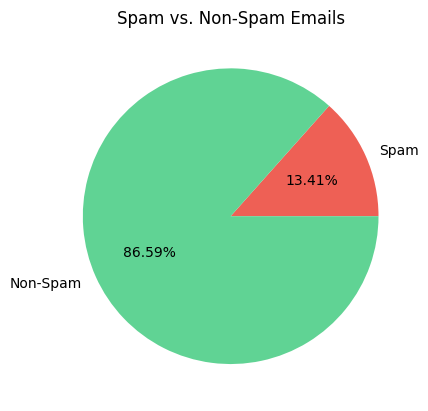

```python
import matplotlib.pyplot as plt

  # Create a list of colors for the pie chart
  colors = ["#EE6055", "#60D394"]

  # Create a pie chart with the spam and non-spam percentages
  plt.pie([spam, ham], labels=["Spam", "Non-Spam"], colors=colors, autopct="%.2f%%")

  # Add a title to the pie chart
  plt.title("Spam vs. Non-Spam Emails")

  # Show the pie chart
  plt.show()
```

The dataset is **imbalanced**.

```python
df_spam = df[df['Category']=='spam']
  df_spam.shape
```

```
(747, 2)
```

```python
df_ham = df[df['Category']=='ham']
  df_ham.shape
```

```
(4825, 2)
```

**Balancing the data**

```python
df_ham_downsampled = df_ham.sample(df_spam.shape[0])
  df_ham_downsampled.shape
```

```
(747, 2)
```

```python
df_balanced = pd.concat([df_ham_downsampled, df_spam])
  df_balanced.shape
```

```
(1494, 2)
```

```python
df_balanced['Category'].value_counts()
```

```
Category
  ham     747
  spam    747
  Name: count, dtype: int64
```

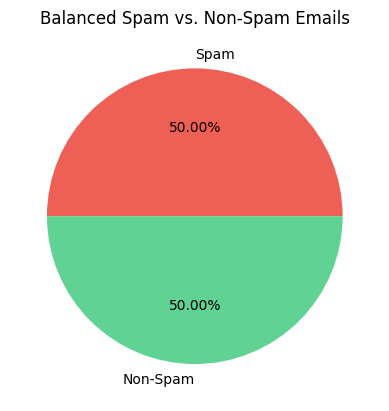

```python
# prompt: plot a pie showing the balanced data

  colors = ["#EE6055", "#60D394"]

  # Create a pie chart with the spam and non-spam percentages
  plt.pie([df_balanced['Category'].value_counts()[1], df_balanced['Category'].value_counts()[0]], labels=["Spam", "Non-Spam"], colors=colors, autopct="%.2f%%")

  # Add a title to the pie chart
  plt.title("Balanced Spam vs. Non-Spam Emails")

  # Show the pie chart
  plt.show()
```

```python
df_balanced['spam']=df_balanced['Category'].apply(lambda x: 1 if x=='spam' else 0)
  df_balanced.sample(10)
```

|  | Category | Message | spam |
| --- | --- | --- | --- |
| 1486 | ham | Hello lover! How goes that new job? Are you th... | 0 |
| 3637 | spam | Customer service announcement. We recently tri... | 1 |
| 4600 | spam | FreeMsg: Txt: CALL to No: 86888 & claim your r... | 1 |
| 3919 | spam | FREE>Ringtone! Reply REAL or POLY eg REAL1 1. ... | 1 |
| 4963 | spam | Dear Voucher holder Have your next meal on us.... | 1 |
| 2461 | ham | Anything lar... | 0 |
| 2214 | ham | Ok then i'll let him noe later n ask him call ... | 0 |
| 4766 | spam | Your unique user ID is 1172. For removal send ... | 1 |
| 4929 | spam | Hi, the SEXYCHAT girls are waiting for you to ... | 1 |
| 1740 | spam | UR GOING 2 BAHAMAS! CallFREEFONE 08081560665 a... | 1 |

**Training and Testing dataset**

```python
from sklearn.model_selection import train_test_split

  X_train, X_test, y_train, y_test = train_test_split(df_balanced['Message'],df_balanced['spam'], stratify=df_balanced['spam'])
```

## **Build a Functional Model using BERT**

```python
bert_preprocess = hub.KerasLayer("https://tfhub.dev/tensorflow/bert_en_uncased_preprocess/3")
  bert_encoder = hub.KerasLayer("https://tfhub.dev/tensorflow/bert_en_uncased_L-12_H-768_A-12/4")
```

```python
# Bert layers
  text_input = tf.keras.layers.Input(shape=(), dtype=tf.string, name='text')
  preprocessed_text = bert_preprocess(text_input)
  outputs = bert_encoder(preprocessed_text)

  # Neural network layers
  l = tf.keras.layers.Dropout(0.1, name="dropout")(outputs['pooled_output'])
  l = tf.keras.layers.Dense(1, activation='sigmoid', name="output")(l)

  # Use inputs and outputs to construct a final model
  model = tf.keras.Model(inputs=[text_input], outputs = [l])
```

**Visualize the model**

```python
#import libraries to visualize the model
  %pip install pydot
  %pip install pydotplus
  %pip install graphviz
```

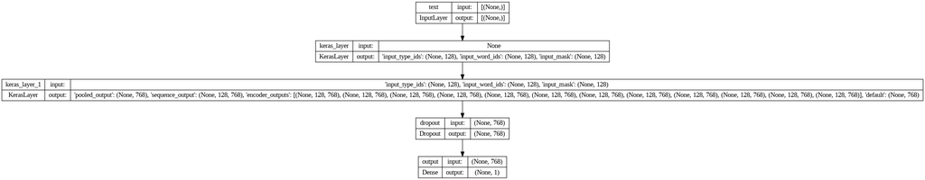

```python
from keras.utils import plot_model
  plot_model(model, to_file='model_plot.png', show_shapes=True, show_layer_names=True)
```

```python
model.summary()
```

```
Model: "model"
  __________________________________________________________________________________________________
   Layer (type)                   Output Shape         Param #     Connected to
  ==================================================================================================
   text (InputLayer)              [(None,)]            0           []

   keras_layer (KerasLayer)       {'input_type_ids':   0           ['text[0][0]']
                                  (None, 128),
                                   'input_word_ids':
                                  (None, 128),
                                   'input_mask': (Non
                                  e, 128)}

   keras_layer_1 (KerasLayer)     {'pooled_output': (  109482241   ['keras_layer[0][0]',
                                  None, 768),                       'keras_layer[0][1]',
                                   'sequence_output':               'keras_layer[0][2]']
                                   (None, 128, 768),
                                   'encoder_outputs':
                                   [(None, 128, 768),
                                   (None, 128, 768),
                                   (None, 128, 768),
                                   (None, 128, 768),
                                   (None, 128, 768),
                                   (None, 128, 768),
                                   (None, 128, 768),
                                   (None, 128, 768),
                                   (None, 128, 768),
                                   (None, 128, 768),
                                   (None, 128, 768),
                                   (None, 128, 768)],
                                   'default': (None,
                                  768)}

   dropout (Dropout)              (None, 768)          0           ['keras_layer_1[0][13]']

   output (Dense)                 (None, 1)            769         ['dropout[0][0]']

  ==================================================================================================
  Total params: 109,483,010
  Trainable params: 769
  Non-trainable params: 109,482,241
  __________________________________________________________________________________________________
```

```python
METRICS = [
        tf.keras.metrics.BinaryAccuracy(name='accuracy'),
        tf.keras.metrics.Precision(name='precision'),
        tf.keras.metrics.Recall(name='recall')
  ]

  model.compile(optimizer='adam',
                loss='binary_crossentropy',
                metrics=METRICS)
```

## **Model Training**

```python
model.fit(X_train,y_train,epochs=20)
```

```
<keras.callbacks.History at 0x7bc0596631c0>
```

## **Model evaluation**

```python
y_predicted = model.predict(X_test)
  y_predicted = y_predicted.flatten()
```

```python
import numpy as np

  y_predicted = np.where(y_predicted > 0.5, 1, 0)
  y_predicted
```

```
array([0, 0, 0, 0, 0, 0, 1, 1, 0, 1, 0, 1, 0, 1, 1, 0, 1, 0, 0, 0, 1, 1,
         0, 0, 1, 1, 1, 0, 0, 0, 1, 0, 1, 0, 0, 0, 1, 0, 0, 1, 0, 0, 0, 0,
         1, 0, 1, 0, 0, 0, 0, 0, 1, 1, 1, 1, 0, 0, 1, 0, 1, 1, 0, 1, 1, 0,
         0, 1, 0, 1, 0, 1, 1, 0, 0, 1, 0, 1, 0, 0, 1, 1, 0, 0, 1, 0, 1, 1,
         1, 1, 1, 0, 0, 1, 1, 1, 1, 1, 1, 0, 1, 1, 0, 0, 1, 0, 0, 1, 0, 0,
         1, 0, 1, 0, 0, 0, 0, 1, 0, 1, 1, 0, 1, 1, 1, 1, 1, 0, 1, 0, 0, 1,
         0, 1, 1, 0, 1, 0, 1, 1, 0, 0, 1, 0, 0, 0, 0, 1, 1, 0, 1, 1, 1, 0,
         1, 0, 1, 0, 0, 0, 1, 0, 1, 1, 1, 0, 0, 1, 1, 0, 0, 0, 1, 1, 0, 0,
         1, 0, 0, 0, 1, 0, 0, 0, 0, 0, 1, 0, 1, 0, 0, 0, 1, 0, 1, 0, 0, 0,
         1, 1, 0, 1, 1, 0, 0, 0, 1, 1, 0, 0, 0, 0, 0, 0, 1, 1, 0, 0, 0, 1,
         1, 1, 1, 0, 1, 1, 0, 1, 0, 0, 1, 1, 0, 0, 0, 1, 1, 0, 1, 0, 1, 1,
         0, 1, 0, 1, 0, 0, 0, 0, 1, 0, 1, 0, 0, 0, 0, 0, 0, 0, 0, 1, 0, 0,
         1, 0, 1, 1, 1, 1, 0, 0, 0, 0, 1, 1, 0, 1, 1, 0, 1, 1, 0, 0, 1, 1,
         0, 0, 0, 0, 0, 0, 0, 0, 0, 0, 0, 0, 0, 0, 1, 0, 1, 1, 0, 0, 1, 1,
         0, 0, 0, 1, 1, 0, 0, 1, 1, 0, 0, 0, 1, 1, 1, 0, 1, 1, 0, 1, 0, 1,
         1, 1, 1, 0, 0, 0, 1, 0, 0, 1, 1, 0, 0, 0, 0, 1, 1, 1, 1, 1, 1, 1,
         0, 1, 1, 1, 1, 1, 1, 1, 0, 1, 0, 0, 0, 0, 1, 1, 1, 0, 0, 1, 0, 1])
```

Spam: **1**

Not Spam: **0**

## Metrics

```python
from sklearn.metrics import accuracy_score, precision_score, recall_score
  loss, accuracy, precision, recall = model.evaluate(X_test, y_test)

  print("Loss:", loss)
  print("Accuracy:", accuracy)
  print("Precision:", precision)
  print("Recall:", recall)
```

```
  Loss: 0.26384904980659485
  Accuracy: 0.9224599003791809
  Precision: 0.9593023061752319
  Recall: 0.8823529481887817
```

## **Predictions**

Values > 0.5 are **spam** = 1

Values <=0.5 are **not spam** = 0

```python
import pandas as pd

  email_sample_dataset = [
      'Our latest newsletter is now available. Click here to read about our recent updates and upcoming events.',
      'Lose 20 pounds in just 2 weeks with this amazing new diet pill!',
      'You have been pre-approved for a $50,000 loan with no credit check.',
      'We would like to invite you to our upcoming webinar on innovative business strategies. Click here to register.',
      'Urgent! Your account has been compromised. Verify your information now.',
      'We are pleased to inform you that your application has been approved. Please review the attached document for further details.',
      'You will not believe this one weird trick to lose belly fat overnight',
      'Earn $10,000 a month with this simple online job',
      'Your monthly bank statement is now available. Please log in to your account to view the details',
      'Earn thousands of dollars a week from home with this simple trick',
      'Congratulations! You\'ve been selected to win a $1,000 gift card',
      'As a valued customer, you are eligible for a special discount on your next purchase. Use the code THANKYOU at checkout.',
      'Thank you for your recent purchase. Your order has been shipped and will arrive in 3-5 business days.',
      'Welcome to our community! Here are some resources to help you get started.',
      'Claim your free $500 Amazon gift card now.',
      'This is not a joke! Click here to get 100% off on all items.',
      'Your appointment is scheduled for June 20th at 10:00 AM. Please let us know if you need to reschedule',
      'Unlock the secrets to wealth and success with this exclusive eBook',
      'Download this attachment to fix critical issues on your computer',
      'Your account has been suspended! Click here to verify your information immediately'
  ]

  email_predictions = model.predict(email_sample_dataset)
  print(email_predictions)

  email_actual_classification = np.array([0,1,1,1,1,0,1,1,0,1,1,0,0,0,1,1,0,1,1,0])

  df = pd.DataFrame({
      'Email_Text': email_sample_dataset,
      'Prediction_Value': email_predictions.flatten(),
      'Actual_Values': email_actual_classification
  })

  df['Actual_Values'] = df['Actual_Values'].apply(lambda x: 'NOT_SPAM' if x == 0 else 'SPAM')

  print(df.to_string())
```

```
  [[0.3732164 ]
   [0.07076167]
   [0.5362863 ]
   [0.3017276 ]
   [0.22100723]
   [0.23692168]
   [0.04441811]
   [0.34470835]
   [0.58636826]
   [0.06882222]
   [0.4638272 ]
   [0.41700122]
   [0.2676421 ]
   [0.405214  ]
   [0.6034726 ]
   [0.28171384]
   [0.5009866 ]
   [0.7152105 ]
   [0.20821066]
   [0.40582687]]
                                                                                                                          Email_Text  Prediction_Value Actual_Values
  0                         Our latest newsletter is now available. Click here to read about our recent updates and upcoming events.          0.373216      NOT_SPAM
  1                                                                  Lose 20 pounds in just 2 weeks with this amazing new diet pill!          0.070762          SPAM
  2                                                              You have been pre-approved for a $50,000 loan with no credit check.          0.536286          SPAM
  3                   We would like to invite you to our upcoming webinar on innovative business strategies. Click here to register.          0.301728          SPAM
  4                                                          Urgent! Your account has been compromised. Verify your information now.          0.221007          SPAM
  5   We are pleased to inform you that your application has been approved. Please review the attached document for further details.          0.236922      NOT_SPAM
  6                                                            You will not believe this one weird trick to lose belly fat overnight          0.044418          SPAM
  7                                                                                 Earn $10,000 a month with this simple online job          0.344708          SPAM
  8                                  Your monthly bank statement is now available. Please log in to your account to view the details          0.586368      NOT_SPAM
  9                                                                Earn thousands of dollars a week from home with this simple trick          0.068822          SPAM
  10                                                                 Congratulations! You've been selected to win a $1,000 gift card          0.463827          SPAM
  11         As a valued customer, you are eligible for a special discount on your next purchase. Use the code THANKYOU at checkout.          0.417001      NOT_SPAM
  12                           Thank you for your recent purchase. Your order has been shipped and will arrive in 3-5 business days.          0.267642      NOT_SPAM
  13                                                      Welcome to our community! Here are some resources to help you get started.          0.405214      NOT_SPAM
  14                                                                                      Claim your free $500 Amazon gift card now.          0.603473          SPAM
  15                                                                    This is not a joke! Click here to get 100% off on all items.          0.281714          SPAM
  16                           Your appointment is scheduled for June 20th at 10:00 AM. Please let us know if you need to reschedule          0.500987      NOT_SPAM
  17                                                              Unlock the secrets to wealth and success with this exclusive eBook          0.715210          SPAM
  18                                                                Download this attachment to fix critical issues on your computer          0.208211          SPAM
  19                                              Your account has been suspended! Click here to verify your information immediately          0.405827      NOT_SPAM
```

We observe that our results aren't exactly good. For example, "Lose 20 pounds in just 2 weeks with this amazing new diet pill!" was classified as NOT_SPAM by our model when it was actually SPAM.

## **Conclusions**

The accuracy of the model was 92.24%, the precision was 95.93%, and the recall was 88.24%. However, when we ran different entries that were made up by ChatGPT, our model failed to perform as was trained with the training dataset and tested with the testing dataset.

In practice, our model only predicted 9 correct entries, failing in the other 11 entries.

We can continue to train our model by not only increasing the number of thresholds, modifying the activation function, increasing or decreasing the number of layers, etc. But also by obtaining larger datasets.

The results show how difficult it is to classify emotions, text, and phrases.